# Risk Factor Analysis

## Outcome Variable

**Outcome Variable:** stunted

## Predictor Variables

**Intervention Variable:** tr

**Adjustment Set:**

unadjusted

## Stratifying Variables

The analysis was stratified on these variable(s):

- agecat
- studyid
- country
- intXnchldlt5

## Data Summary

| agecat | studyid | country | intXnchldlt5 | stunted | n_cell | n |
| --- | --- | --- | --- | --- | --- | --- |
| Birth | kiGH5241-JiVitA-3 | BANGLADESH | 1_Birth | 0 | 15730 | 24208 |
| Birth | kiGH5241-JiVitA-3 | BANGLADESH | 1_Birth | 1 | 8478 | 24208 |
| Birth | kiGH5241-JiVitA-3 | BANGLADESH | 2+_Birth | 0 | 690 | 934 |
| Birth | kiGH5241-JiVitA-3 | BANGLADESH | 2+_Birth | 1 | 244 | 934 |
| 6 months | iLiNS_DYADM_LNS | MALAWI | 1_6 months | 0 | 38 | 42 |
| 6 months | iLiNS_DYADM_LNS | MALAWI | 1_6 months | 1 | 4 | 42 |
| 6 months | iLiNS_DYADM_LNS | MALAWI | 2+_6 months | 0 | 28 | 33 |
| 6 months | iLiNS_DYADM_LNS | MALAWI | 2+_6 months | 1 | 5 | 33 |
| 6 months | ki1000107-Serrinha-VitA | BRAZIL | 1_6 months | 0 | 14 | 16 |
| 6 months | ki1000107-Serrinha-VitA | BRAZIL | 1_6 months | 1 | 2 | 16 |
| 6 months | ki1000107-Serrinha-VitA | BRAZIL | 2+_6 months | 0 | 3 | 6 |
| 6 months | ki1000107-Serrinha-VitA | BRAZIL | 2+_6 months | 1 | 3 | 6 |
| 6 months | ki1017093b-PROVIDE | BANGLADESH | 1_6 months | 0 | 23 | 29 |
| 6 months | ki1017093b-PROVIDE | BANGLADESH | 1_6 months | 1 | 6 | 29 |
| 6 months | ki1066203-TanzaniaChild2 | TANZANIA, UNITED REPUBLIC OF | 1_6 months | 0 | 1052 | 1173 |
| 6 months | ki1066203-TanzaniaChild2 | TANZANIA, UNITED REPUBLIC OF | 1_6 months | 1 | 121 | 1173 |
| 6 months | ki1066203-TanzaniaChild2 | TANZANIA, UNITED REPUBLIC OF | 2+_6 months | 0 | 46 | 53 |
| 6 months | ki1066203-TanzaniaChild2 | TANZANIA, UNITED REPUBLIC OF | 2+_6 months | 1 | 7 | 53 |
| 6 months | ki1148112-iLiNS-DOSE | MALAWI | 1_6 months | 0 | 595 | 845 |
| 6 months | ki1148112-iLiNS-DOSE | MALAWI | 1_6 months | 1 | 250 | 845 |
| 6 months | ki1148112-iLiNS-DOSE | MALAWI | 2+_6 months | 0 | 92 | 150 |
| 6 months | ki1148112-iLiNS-DOSE | MALAWI | 2+_6 months | 1 | 58 | 150 |
| 6 months | ki1148112-iLiNS-DYAD-M | MALAWI | 1_6 months | 0 | 53 | 60 |
| 6 months | ki1148112-iLiNS-DYAD-M | MALAWI | 1_6 months | 1 | 7 | 60 |
| 6 months | ki1148112-iLiNS-DYAD-M | MALAWI | 2+_6 months | 0 | 35 | 43 |
| 6 months | ki1148112-iLiNS-DYAD-M | MALAWI | 2+_6 months | 1 | 8 | 43 |
| 6 months | ki1148112-LCNI-5 | MALAWI | 1_6 months | 0 | 263 | 390 |
| 6 months | ki1148112-LCNI-5 | MALAWI | 1_6 months | 1 | 127 | 390 |
| 6 months | ki1148112-LCNI-5 | MALAWI | 2+_6 months | 0 | 37 | 63 |
| 6 months | ki1148112-LCNI-5 | MALAWI | 2+_6 months | 1 | 26 | 63 |
| 6 months | kiGH5241-JiVitA-3 | BANGLADESH | 1_6 months | 0 | 16106 | 21667 |
| 6 months | kiGH5241-JiVitA-3 | BANGLADESH | 1_6 months | 1 | 5561 | 21667 |
| 6 months | kiGH5241-JiVitA-3 | BANGLADESH | 2+_6 months | 0 | 535 | 719 |
| 6 months | kiGH5241-JiVitA-3 | BANGLADESH | 2+_6 months | 1 | 184 | 719 |
| 24 months | iLiNS_DYADM_LNS | MALAWI | 2+_24 months | 0 | 0 | 2 |
| 24 months | iLiNS_DYADM_LNS | MALAWI | 2+_24 months | 1 | 2 | 2 |
| 24 months | ki1000107-Serrinha-VitA | BRAZIL | 1_24 months | 0 | 34 | 50 |
| 24 months | ki1000107-Serrinha-VitA | BRAZIL | 1_24 months | 1 | 16 | 50 |
| 24 months | ki1000107-Serrinha-VitA | BRAZIL | 2+_24 months | 0 | 14 | 29 |
| 24 months | ki1000107-Serrinha-VitA | BRAZIL | 2+_24 months | 1 | 15 | 29 |
| 24 months | ki1017093b-PROVIDE | BANGLADESH | 1_24 months | 0 | 1 | 1 |
| 24 months | ki1017093b-PROVIDE | BANGLADESH | 1_24 months | 1 | 0 | 1 |
| 24 months | ki1066203-TanzaniaChild2 | TANZANIA, UNITED REPUBLIC OF | 1_24 months | 0 | 3 | 4 |
| 24 months | ki1066203-TanzaniaChild2 | TANZANIA, UNITED REPUBLIC OF | 1_24 months | 1 | 1 | 4 |
| 24 months | ki1148112-iLiNS-DOSE | MALAWI | 1_24 months | 0 | 179 | 347 |
| 24 months | ki1148112-iLiNS-DOSE | MALAWI | 1_24 months | 1 | 168 | 347 |
| 24 months | ki1148112-iLiNS-DOSE | MALAWI | 2+_24 months | 0 | 21 | 59 |
| 24 months | ki1148112-iLiNS-DOSE | MALAWI | 2+_24 months | 1 | 38 | 59 |
| 24 months | ki1148112-iLiNS-DYAD-M | MALAWI | 2+_24 months | 0 | 0 | 2 |
| 24 months | ki1148112-iLiNS-DYAD-M | MALAWI | 2+_24 months | 1 | 2 | 2 |
| 24 months | ki1148112-LCNI-5 | MALAWI | 1_24 months | 0 | 122 | 181 |
| 24 months | ki1148112-LCNI-5 | MALAWI | 1_24 months | 1 | 59 | 181 |
| 24 months | ki1148112-LCNI-5 | MALAWI | 2+_24 months | 0 | 14 | 26 |
| 24 months | ki1148112-LCNI-5 | MALAWI | 2+_24 months | 1 | 12 | 26 |
| 24 months | kiGH5241-JiVitA-3 | BANGLADESH | 1_24 months | 0 | 57 | 121 |
| 24 months | kiGH5241-JiVitA-3 | BANGLADESH | 1_24 months | 1 | 64 | 121 |
| 24 months | kiGH5241-JiVitA-3 | BANGLADESH | 2+_24 months | 0 | 3 | 5 |
| 24 months | kiGH5241-JiVitA-3 | BANGLADESH | 2+_24 months | 1 | 2 | 5 |

The following strata were considered:

- agecat: 24 months, studyid: iLiNS_DYADM_LNS, country: MALAWI, intXnchldlt5: 2+_24 months
- agecat: 24 months, studyid: ki1000107-Serrinha-VitA, country: BRAZIL, intXnchldlt5: 1_24 months
- agecat: 24 months, studyid: ki1000107-Serrinha-VitA, country: BRAZIL, intXnchldlt5: 2+_24 months
- agecat: 24 months, studyid: ki1017093b-PROVIDE, country: BANGLADESH, intXnchldlt5: 1_24 months
- agecat: 24 months, studyid: ki1066203-TanzaniaChild2, country: TANZANIA, UNITED REPUBLIC OF, intXnchldlt5: 1_24 months
- agecat: 24 months, studyid: ki1148112-iLiNS-DOSE, country: MALAWI, intXnchldlt5: 1_24 months
- agecat: 24 months, studyid: ki1148112-iLiNS-DOSE, country: MALAWI, intXnchldlt5: 2+_24 months
- agecat: 24 months, studyid: ki1148112-iLiNS-DYAD-M, country: MALAWI, intXnchldlt5: 2+_24 months
- agecat: 24 months, studyid: ki1148112-LCNI-5, country: MALAWI, intXnchldlt5: 1_24 months
- agecat: 24 months, studyid: ki1148112-LCNI-5, country: MALAWI, intXnchldlt5: 2+_24 months
- agecat: 24 months, studyid: kiGH5241-JiVitA-3, country: BANGLADESH, intXnchldlt5: 1_24 months
- agecat: 24 months, studyid: kiGH5241-JiVitA-3, country: BANGLADESH, intXnchldlt5: 2+_24 months
- agecat: 6 months, studyid: iLiNS_DYADM_LNS, country: MALAWI, intXnchldlt5: 1_6 months
- agecat: 6 months, studyid: iLiNS_DYADM_LNS, country: MALAWI, intXnchldlt5: 2+_6 months
- agecat: 6 months, studyid: ki1000107-Serrinha-VitA, country: BRAZIL, intXnchldlt5: 1_6 months
- agecat: 6 months, studyid: ki1000107-Serrinha-VitA, country: BRAZIL, intXnchldlt5: 2+_6 months
- agecat: 6 months, studyid: ki1017093b-PROVIDE, country: BANGLADESH, intXnchldlt5: 1_6 months
- agecat: 6 months, studyid: ki1066203-TanzaniaChild2, country: TANZANIA, UNITED REPUBLIC OF, intXnchldlt5: 1_6 months
- agecat: 6 months, studyid: ki1066203-TanzaniaChild2, country: TANZANIA, UNITED REPUBLIC OF, intXnchldlt5: 2+_6 months
- agecat: 6 months, studyid: ki1148112-iLiNS-DOSE, country: MALAWI, intXnchldlt5: 1_6 months
- agecat: 6 months, studyid: ki1148112-iLiNS-DOSE, country: MALAWI, intXnchldlt5: 2+_6 months
- agecat: 6 months, studyid: ki1148112-iLiNS-DYAD-M, country: MALAWI, intXnchldlt5: 1_6 months
- agecat: 6 months, studyid: ki1148112-iLiNS-DYAD-M, country: MALAWI, intXnchldlt5: 2+_6 months
- agecat: 6 months, studyid: ki1148112-LCNI-5, country: MALAWI, intXnchldlt5: 1_6 months
- agecat: 6 months, studyid: ki1148112-LCNI-5, country: MALAWI, intXnchldlt5: 2+_6 months
- agecat: 6 months, studyid: kiGH5241-JiVitA-3, country: BANGLADESH, intXnchldlt5: 1_6 months
- agecat: 6 months, studyid: kiGH5241-JiVitA-3, country: BANGLADESH, intXnchldlt5: 2+_6 months
- agecat: Birth, studyid: kiGH5241-JiVitA-3, country: BANGLADESH, intXnchldlt5: 1_Birth
- agecat: Birth, studyid: kiGH5241-JiVitA-3, country: BANGLADESH, intXnchldlt5: 2+_Birth

### Dropped Strata

Some strata were dropped due to rare outcomes:

- agecat: 6 months, studyid: iLiNS_DYADM_LNS, country: MALAWI, intXnchldlt5: 1_6 months
- agecat: 6 months, studyid: ki1000107-Serrinha-VitA, country: BRAZIL, intXnchldlt5: 1_6 months
- agecat: 6 months, studyid: ki1000107-Serrinha-VitA, country: BRAZIL, intXnchldlt5: 2+_6 months
- agecat: 24 months, studyid: iLiNS_DYADM_LNS, country: MALAWI, intXnchldlt5: 2+_24 months
- agecat: 24 months, studyid: ki1017093b-PROVIDE, country: BANGLADESH, intXnchldlt5: 1_24 months
- agecat: 24 months, studyid: ki1066203-TanzaniaChild2, country: TANZANIA, UNITED REPUBLIC OF, intXnchldlt5: 1_24 months
- agecat: 24 months, studyid: ki1148112-iLiNS-DYAD-M, country: MALAWI, intXnchldlt5: 2+_24 months
- agecat: 24 months, studyid: kiGH5241-JiVitA-3, country: BANGLADESH, intXnchldlt5: 2+_24 months

## Methods Detail

We’re interested in the causal parameters $E[Y_a]$ for all values of $a \in \mathcal{A}$. These parameters represent the mean outcome if, possibly contrary to fact, we intervened to set all units to have $A=a$. Under the randomization and positivity assumptions, these are identified by the statistical parameters $\psi_a=E_W[E_{Y|A,W}(Y|A=a,W)]$. In addition, we’re interested in the mean of $Y$, $E[Y]$ under no intervention (the observed mean). We will estimate these parameters by using SuperLearner to fit the relevant likelihood factors – $E_{Y|A,W}(Y|A=a,W)$ and $p(A=a|W)$, and then updating our likelihood fit using a joint TMLE.

For unadjusted analyses ($W=\{\}$), initial likelihoods were estimated using Lrnr_glm to estimate the simple $E(Y|A)$ and Lrnr_mean to estimate $p(A)$. For adjusted analyses, a small library containing Lrnr_glmnet, Lrnr_xgboost, and Lrnr_mean was used.

Having estimated these parameters, we will then use the delta method to estimate relative risks and attributable risks relative to a prespecified baseline level of $A$.

# Results Detail

## Results Plots

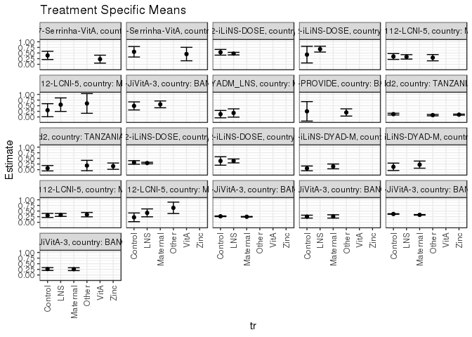

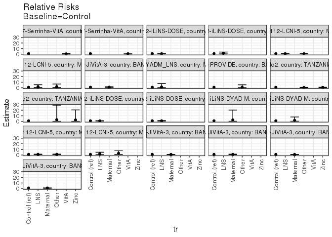

[figure not shown]

[figure not shown]

## Results Table

### Parameter: TSM

| agecat | studyid | country | intXnchldlt5 | intervention_level | baseline_level | estimate | ci_lower | ci_upper |
| --- | --- | --- | --- | --- | --- | --- | --- | --- |
| Birth | kiGH5241-JiVitA-3 | BANGLADESH | 1_Birth | Control | NA | 0.3691130 | 0.3555767 | 0.3826493 |
| Birth | kiGH5241-JiVitA-3 | BANGLADESH | 1_Birth | Maternal | NA | 0.3315833 | 0.3182020 | 0.3449645 |
| Birth | kiGH5241-JiVitA-3 | BANGLADESH | 2+_Birth | Control | NA | 0.2635983 | 0.2019324 | 0.3252643 |
| Birth | kiGH5241-JiVitA-3 | BANGLADESH | 2+_Birth | Maternal | NA | 0.2587719 | 0.1958567 | 0.3216872 |
| 6 months | iLiNS_DYADM_LNS | MALAWI | 2+_6 months | Control | NA | 0.1250000 | -0.0395618 | 0.2895618 |
| 6 months | iLiNS_DYADM_LNS | MALAWI | 2+_6 months | LNS | NA | 0.1764706 | -0.0075563 | 0.3604975 |
| 6 months | ki1017093b-PROVIDE | BANGLADESH | 1_6 months | Control | NA | 0.2500000 | -0.1818558 | 0.6818558 |
| 6 months | ki1017093b-PROVIDE | BANGLADESH | 1_6 months | Other | NA | 0.2000000 | 0.0404275 | 0.3595725 |
| 6 months | ki1066203-TanzaniaChild2 | TANZANIA, UNITED REPUBLIC OF | 1_6 months | Control | NA | 0.1258503 | 0.0879206 | 0.1637801 |
| 6 months | ki1066203-TanzaniaChild2 | TANZANIA, UNITED REPUBLIC OF | 1_6 months | Other | NA | 0.0816993 | 0.0509968 | 0.1124019 |
| 6 months | ki1066203-TanzaniaChild2 | TANZANIA, UNITED REPUBLIC OF | 1_6 months | Zinc | NA | 0.1029668 | 0.0780720 | 0.1278617 |
| 6 months | ki1066203-TanzaniaChild2 | TANZANIA, UNITED REPUBLIC OF | 2+_6 months | Control | NA | 0.0625000 | -0.0572430 | 0.1822430 |
| 6 months | ki1066203-TanzaniaChild2 | TANZANIA, UNITED REPUBLIC OF | 2+_6 months | Other | NA | 0.1818182 | -0.0482897 | 0.4119261 |
| 6 months | ki1066203-TanzaniaChild2 | TANZANIA, UNITED REPUBLIC OF | 2+_6 months | Zinc | NA | 0.1538462 | 0.0138340 | 0.2938583 |
| 6 months | ki1148112-iLiNS-DOSE | MALAWI | 1_6 months | Control | NA | 0.3185185 | 0.2398805 | 0.3971566 |
| 6 months | ki1148112-iLiNS-DOSE | MALAWI | 1_6 months | LNS | NA | 0.2915493 | 0.2581000 | 0.3249986 |
| 6 months | ki1148112-iLiNS-DOSE | MALAWI | 2+_6 months | Control | NA | 0.3846154 | 0.1969861 | 0.5722446 |
| 6 months | ki1148112-iLiNS-DOSE | MALAWI | 2+_6 months | LNS | NA | 0.3870968 | 0.3010776 | 0.4731160 |
| 6 months | ki1148112-iLiNS-DYAD-M | MALAWI | 1_6 months | Control | NA | 0.0555556 | -0.0511565 | 0.1622676 |
| 6 months | ki1148112-iLiNS-DYAD-M | MALAWI | 1_6 months | Maternal | NA | 0.1428571 | 0.0361360 | 0.2495783 |
| 6 months | ki1148112-iLiNS-DYAD-M | MALAWI | 2+_6 months | Control | NA | 0.1250000 | -0.0389671 | 0.2889671 |
| 6 months | ki1148112-iLiNS-DYAD-M | MALAWI | 2+_6 months | Maternal | NA | 0.2222222 | 0.0635513 | 0.3808931 |
| 6 months | ki1148112-LCNI-5 | MALAWI | 1_6 months | Control | NA | 0.3061224 | 0.2147571 | 0.3974878 |
| 6 months | ki1148112-LCNI-5 | MALAWI | 1_6 months | LNS | NA | 0.3283582 | 0.2633527 | 0.3933637 |
| 6 months | ki1148112-LCNI-5 | MALAWI | 1_6 months | Other | NA | 0.3406593 | 0.2431604 | 0.4381583 |
| 6 months | ki1148112-LCNI-5 | MALAWI | 2+_6 months | Control | NA | 0.2222222 | 0.0286211 | 0.4158233 |
| 6 months | ki1148112-LCNI-5 | MALAWI | 2+_6 months | LNS | NA | 0.4193548 | 0.2442541 | 0.5944555 |
| 6 months | ki1148112-LCNI-5 | MALAWI | 2+_6 months | Other | NA | 0.6428571 | 0.3898477 | 0.8958666 |
| 6 months | kiGH5241-JiVitA-3 | BANGLADESH | 1_6 months | Control | NA | 0.2672333 | 0.2525904 | 0.2818763 |
| 6 months | kiGH5241-JiVitA-3 | BANGLADESH | 1_6 months | Maternal | NA | 0.2463279 | 0.2331089 | 0.2595469 |
| 6 months | kiGH5241-JiVitA-3 | BANGLADESH | 2+_6 months | Control | NA | 0.2513661 | 0.1868254 | 0.3159068 |
| 6 months | kiGH5241-JiVitA-3 | BANGLADESH | 2+_6 months | Maternal | NA | 0.2606232 | 0.1874300 | 0.3338165 |
| 24 months | ki1000107-Serrinha-VitA | BRAZIL | 1_24 months | Control | NA | 0.3928571 | 0.2101234 | 0.5755909 |
| 24 months | ki1000107-Serrinha-VitA | BRAZIL | 1_24 months | VitA | NA | 0.2272727 | 0.0503798 | 0.4041657 |
| 24 months | ki1000107-Serrinha-VitA | BRAZIL | 2+_24 months | Control | NA | 0.5555556 | 0.3219386 | 0.7891725 |
| 24 months | ki1000107-Serrinha-VitA | BRAZIL | 2+_24 months | VitA | NA | 0.4545455 | 0.1550849 | 0.7540060 |
| 24 months | ki1148112-iLiNS-DOSE | MALAWI | 1_24 months | Control | NA | 0.5333333 | 0.4069174 | 0.6597493 |
| 24 months | ki1148112-iLiNS-DOSE | MALAWI | 1_24 months | LNS | NA | 0.4738676 | 0.4160167 | 0.5317185 |
| 24 months | ki1148112-iLiNS-DOSE | MALAWI | 2+_24 months | Control | NA | 0.4285714 | 0.0588253 | 0.7983176 |
| 24 months | ki1148112-iLiNS-DOSE | MALAWI | 2+_24 months | LNS | NA | 0.6730769 | 0.5444850 | 0.8016688 |
| 24 months | ki1148112-LCNI-5 | MALAWI | 1_24 months | Control | NA | 0.3461538 | 0.2164891 | 0.4758186 |
| 24 months | ki1148112-LCNI-5 | MALAWI | 1_24 months | LNS | NA | 0.3295455 | 0.2310645 | 0.4280264 |
| 24 months | ki1148112-LCNI-5 | MALAWI | 1_24 months | Other | NA | 0.2926829 | 0.1530252 | 0.4323407 |
| 24 months | ki1148112-LCNI-5 | MALAWI | 2+_24 months | Control | NA | 0.3000000 | 0.0103494 | 0.5896506 |
| 24 months | ki1148112-LCNI-5 | MALAWI | 2+_24 months | LNS | NA | 0.5454545 | 0.2453750 | 0.8455341 |
| 24 months | ki1148112-LCNI-5 | MALAWI | 2+_24 months | Other | NA | 0.6000000 | 0.1620895 | 1.0379105 |
| 24 months | kiGH5241-JiVitA-3 | BANGLADESH | 1_24 months | Control | NA | 0.4905660 | 0.3114087 | 0.6697234 |
| 24 months | kiGH5241-JiVitA-3 | BANGLADESH | 1_24 months | Maternal | NA | 0.5588235 | 0.4091539 | 0.7084932 |

### Parameter: E(Y)

| agecat | studyid | country | intXnchldlt5 | intervention_level | baseline_level | estimate | ci_lower | ci_upper |
| --- | --- | --- | --- | --- | --- | --- | --- | --- |
| Birth | kiGH5241-JiVitA-3 | BANGLADESH | 1_Birth | NA | NA | 0.3502148 | 0.3405588 | 0.3598708 |
| Birth | kiGH5241-JiVitA-3 | BANGLADESH | 2+_Birth | NA | NA | 0.2612420 | 0.2171986 | 0.3052854 |
| 6 months | iLiNS_DYADM_LNS | MALAWI | 2+_6 months | NA | NA | 0.1515152 | 0.0272861 | 0.2757442 |
| 6 months | ki1017093b-PROVIDE | BANGLADESH | 1_6 months | NA | NA | 0.2068966 | 0.0568553 | 0.3569378 |
| 6 months | ki1066203-TanzaniaChild2 | TANZANIA, UNITED REPUBLIC OF | 1_6 months | NA | NA | 0.1031543 | 0.0857408 | 0.1205678 |
| 6 months | ki1066203-TanzaniaChild2 | TANZANIA, UNITED REPUBLIC OF | 2+_6 months | NA | NA | 0.1320755 | 0.0400520 | 0.2240989 |
| 6 months | ki1148112-iLiNS-DOSE | MALAWI | 1_6 months | NA | NA | 0.2958580 | 0.2650652 | 0.3266508 |
| 6 months | ki1148112-iLiNS-DOSE | MALAWI | 2+_6 months | NA | NA | 0.3866667 | 0.3084730 | 0.4648603 |
| 6 months | ki1148112-iLiNS-DYAD-M | MALAWI | 1_6 months | NA | NA | 0.1166667 | 0.0347527 | 0.1985806 |
| 6 months | ki1148112-iLiNS-DYAD-M | MALAWI | 2+_6 months | NA | NA | 0.1860465 | 0.0683580 | 0.3037350 |
| 6 months | ki1148112-LCNI-5 | MALAWI | 1_6 months | NA | NA | 0.3256410 | 0.2790729 | 0.3722091 |
| 6 months | ki1148112-LCNI-5 | MALAWI | 2+_6 months | NA | NA | 0.4126984 | 0.2901524 | 0.5352444 |
| 6 months | kiGH5241-JiVitA-3 | BANGLADESH | 1_6 months | NA | NA | 0.2566576 | 0.2467626 | 0.2665526 |
| 6 months | kiGH5241-JiVitA-3 | BANGLADESH | 2+_6 months | NA | NA | 0.2559110 | 0.2071800 | 0.3046420 |
| 24 months | ki1000107-Serrinha-VitA | BRAZIL | 1_24 months | NA | NA | 0.3200000 | 0.1893891 | 0.4506109 |
| 24 months | ki1000107-Serrinha-VitA | BRAZIL | 2+_24 months | NA | NA | 0.5172414 | 0.3321523 | 0.7023304 |
| 24 months | ki1148112-iLiNS-DOSE | MALAWI | 1_24 months | NA | NA | 0.4841499 | 0.4314922 | 0.5368075 |
| 24 months | ki1148112-iLiNS-DOSE | MALAWI | 2+_24 months | NA | NA | 0.6440678 | 0.5208471 | 0.7672885 |
| 24 months | ki1148112-LCNI-5 | MALAWI | 1_24 months | NA | NA | 0.3259669 | 0.2574907 | 0.3944430 |
| 24 months | ki1148112-LCNI-5 | MALAWI | 2+_24 months | NA | NA | 0.4615385 | 0.2661228 | 0.6569541 |
| 24 months | kiGH5241-JiVitA-3 | BANGLADESH | 1_24 months | NA | NA | 0.5289256 | 0.4136162 | 0.6442351 |

### Parameter: RR

| agecat | studyid | country | intXnchldlt5 | intervention_level | baseline_level | estimate | ci_lower | ci_upper |
| --- | --- | --- | --- | --- | --- | --- | --- | --- |
| Birth | kiGH5241-JiVitA-3 | BANGLADESH | 1_Birth | Control | Control | 1.0000000 | 1.0000000 | 1.0000000 |
| Birth | kiGH5241-JiVitA-3 | BANGLADESH | 1_Birth | Maternal | Control | 0.8983245 | 0.8506314 | 0.9486917 |
| Birth | kiGH5241-JiVitA-3 | BANGLADESH | 2+_Birth | Control | Control | 1.0000000 | 1.0000000 | 1.0000000 |
| Birth | kiGH5241-JiVitA-3 | BANGLADESH | 2+_Birth | Maternal | Control | 0.9816903 | 0.7005593 | 1.3756379 |
| 6 months | iLiNS_DYADM_LNS | MALAWI | 2+_6 months | Control | Control | 1.0000000 | 1.0000000 | 1.0000000 |
| 6 months | iLiNS_DYADM_LNS | MALAWI | 2+_6 months | LNS | Control | 1.4117647 | 0.2632549 | 7.5709126 |
| 6 months | ki1017093b-PROVIDE | BANGLADESH | 1_6 months | Control | Control | 1.0000000 | 1.0000000 | 1.0000000 |
| 6 months | ki1017093b-PROVIDE | BANGLADESH | 1_6 months | Other | Control | 0.8000000 | 0.1193226 | 5.3636102 |
| 6 months | ki1066203-TanzaniaChild2 | TANZANIA, UNITED REPUBLIC OF | 1_6 months | Control | Control | 1.0000000 | 1.0000000 | 1.0000000 |
| 6 months | ki1066203-TanzaniaChild2 | TANZANIA, UNITED REPUBLIC OF | 1_6 months | Other | Control | 0.6491786 | 0.4010084 | 1.0509327 |
| 6 months | ki1066203-TanzaniaChild2 | TANZANIA, UNITED REPUBLIC OF | 1_6 months | Zinc | Control | 0.8181690 | 0.5559557 | 1.2040535 |
| 6 months | ki1066203-TanzaniaChild2 | TANZANIA, UNITED REPUBLIC OF | 2+_6 months | Control | Control | 1.0000000 | 1.0000000 | 1.0000000 |
| 6 months | ki1066203-TanzaniaChild2 | TANZANIA, UNITED REPUBLIC OF | 2+_6 months | Other | Control | 2.9090909 | 0.2927842 | 28.9046035 |
| 6 months | ki1066203-TanzaniaChild2 | TANZANIA, UNITED REPUBLIC OF | 2+_6 months | Zinc | Control | 2.4615385 | 0.2951513 | 20.5290327 |
| 6 months | ki1148112-iLiNS-DOSE | MALAWI | 1_6 months | Control | Control | 1.0000000 | 1.0000000 | 1.0000000 |
| 6 months | ki1148112-iLiNS-DOSE | MALAWI | 1_6 months | LNS | Control | 0.9153292 | 0.6971784 | 1.2017406 |
| 6 months | ki1148112-iLiNS-DOSE | MALAWI | 2+_6 months | Control | Control | 1.0000000 | 1.0000000 | 1.0000000 |
| 6 months | ki1148112-iLiNS-DOSE | MALAWI | 2+_6 months | LNS | Control | 1.0064516 | 0.5888212 | 1.7202927 |
| 6 months | ki1148112-iLiNS-DYAD-M | MALAWI | 1_6 months | Control | Control | 1.0000000 | 1.0000000 | 1.0000000 |
| 6 months | ki1148112-iLiNS-DYAD-M | MALAWI | 1_6 months | Maternal | Control | 2.5714286 | 0.3274194 | 20.1950312 |
| 6 months | ki1148112-iLiNS-DYAD-M | MALAWI | 2+_6 months | Control | Control | 1.0000000 | 1.0000000 | 1.0000000 |
| 6 months | ki1148112-iLiNS-DYAD-M | MALAWI | 2+_6 months | Maternal | Control | 1.7777778 | 0.3992714 | 7.9156530 |
| 6 months | ki1148112-LCNI-5 | MALAWI | 1_6 months | Control | Control | 1.0000000 | 1.0000000 | 1.0000000 |
| 6 months | ki1148112-LCNI-5 | MALAWI | 1_6 months | LNS | Control | 1.0726368 | 0.7497393 | 1.5345997 |
| 6 months | ki1148112-LCNI-5 | MALAWI | 1_6 months | Other | Control | 1.1128205 | 0.7359340 | 1.6827182 |
| 6 months | ki1148112-LCNI-5 | MALAWI | 2+_6 months | Control | Control | 1.0000000 | 1.0000000 | 1.0000000 |
| 6 months | ki1148112-LCNI-5 | MALAWI | 2+_6 months | LNS | Control | 1.8870968 | 0.7181636 | 4.9586668 |
| 6 months | ki1148112-LCNI-5 | MALAWI | 2+_6 months | Other | Control | 2.8928571 | 1.1121175 | 7.5249445 |
| 6 months | kiGH5241-JiVitA-3 | BANGLADESH | 1_6 months | Control | Control | 1.0000000 | 1.0000000 | 1.0000000 |
| 6 months | kiGH5241-JiVitA-3 | BANGLADESH | 1_6 months | Maternal | Control | 0.9217708 | 0.8537170 | 0.9952496 |
| 6 months | kiGH5241-JiVitA-3 | BANGLADESH | 2+_6 months | Control | Control | 1.0000000 | 1.0000000 | 1.0000000 |
| 6 months | kiGH5241-JiVitA-3 | BANGLADESH | 2+_6 months | Maternal | Control | 1.0368272 | 0.7087628 | 1.5167426 |
| 24 months | ki1000107-Serrinha-VitA | BRAZIL | 1_24 months | Control | Control | 1.0000000 | 1.0000000 | 1.0000000 |
| 24 months | ki1000107-Serrinha-VitA | BRAZIL | 1_24 months | VitA | Control | 0.5785124 | 0.2336290 | 1.4325133 |
| 24 months | ki1000107-Serrinha-VitA | BRAZIL | 2+_24 months | Control | Control | 1.0000000 | 1.0000000 | 1.0000000 |
| 24 months | ki1000107-Serrinha-VitA | BRAZIL | 2+_24 months | VitA | Control | 0.8181818 | 0.3744681 | 1.7876595 |
| 24 months | ki1148112-iLiNS-DOSE | MALAWI | 1_24 months | Control | Control | 1.0000000 | 1.0000000 | 1.0000000 |
| 24 months | ki1148112-iLiNS-DOSE | MALAWI | 1_24 months | LNS | Control | 0.8885017 | 0.6805591 | 1.1599806 |
| 24 months | ki1148112-iLiNS-DOSE | MALAWI | 2+_24 months | Control | Control | 1.0000000 | 1.0000000 | 1.0000000 |
| 24 months | ki1148112-iLiNS-DOSE | MALAWI | 2+_24 months | LNS | Control | 1.5705128 | 0.6490540 | 3.8001624 |
| 24 months | ki1148112-LCNI-5 | MALAWI | 1_24 months | Control | Control | 1.0000000 | 1.0000000 | 1.0000000 |
| 24 months | ki1148112-LCNI-5 | MALAWI | 1_24 months | LNS | Control | 0.9520202 | 0.5895736 | 1.5372848 |
| 24 months | ki1148112-LCNI-5 | MALAWI | 1_24 months | Other | Control | 0.8455285 | 0.4609692 | 1.5509028 |
| 24 months | ki1148112-LCNI-5 | MALAWI | 2+_24 months | Control | Control | 1.0000000 | 1.0000000 | 1.0000000 |
| 24 months | ki1148112-LCNI-5 | MALAWI | 2+_24 months | LNS | Control | 1.8181818 | 0.5984555 | 5.5238608 |
| 24 months | ki1148112-LCNI-5 | MALAWI | 2+_24 months | Other | Control | 2.0000000 | 0.5962033 | 6.7091209 |
| 24 months | kiGH5241-JiVitA-3 | BANGLADESH | 1_24 months | Control | Control | 1.0000000 | 1.0000000 | 1.0000000 |
| 24 months | kiGH5241-JiVitA-3 | BANGLADESH | 1_24 months | Maternal | Control | 1.1391403 | 0.7242405 | 1.7917260 |

### Parameter: PAR

| agecat | studyid | country | intXnchldlt5 | intervention_level | baseline_level | estimate | ci_lower | ci_upper |
| --- | --- | --- | --- | --- | --- | --- | --- | --- |
| Birth | kiGH5241-JiVitA-3 | BANGLADESH | 1_Birth | Control | NA | -0.0188982 | -0.0286706 | -0.0091258 |
| Birth | kiGH5241-JiVitA-3 | BANGLADESH | 2+_Birth | Control | NA | -0.0023564 | -0.0453683 | 0.0406555 |
| 6 months | iLiNS_DYADM_LNS | MALAWI | 2+_6 months | Control | NA | 0.0265152 | -0.1009740 | 0.1540043 |
| 6 months | ki1017093b-PROVIDE | BANGLADESH | 1_6 months | Control | NA | -0.0431034 | -0.4400463 | 0.3538394 |
| 6 months | ki1066203-TanzaniaChild2 | TANZANIA, UNITED REPUBLIC OF | 1_6 months | Control | NA | -0.0226960 | -0.0546448 | 0.0092527 |
| 6 months | ki1066203-TanzaniaChild2 | TANZANIA, UNITED REPUBLIC OF | 2+_6 months | Control | NA | 0.0695755 | -0.0493764 | 0.1885274 |
| 6 months | ki1148112-iLiNS-DOSE | MALAWI | 1_6 months | Control | NA | -0.0226605 | -0.0944672 | 0.0491462 |
| 6 months | ki1148112-iLiNS-DOSE | MALAWI | 2+_6 months | Control | NA | 0.0020513 | -0.1685790 | 0.1726815 |
| 6 months | ki1148112-iLiNS-DYAD-M | MALAWI | 1_6 months | Control | NA | 0.0611111 | -0.0450250 | 0.1672472 |
| 6 months | ki1148112-iLiNS-DYAD-M | MALAWI | 2+_6 months | Control | NA | 0.0610465 | -0.0829264 | 0.2050194 |
| 6 months | ki1148112-LCNI-5 | MALAWI | 1_6 months | Control | NA | 0.0195186 | -0.0599861 | 0.0990233 |
| 6 months | ki1148112-LCNI-5 | MALAWI | 2+_6 months | Control | NA | 0.1904762 | 0.0141782 | 0.3667742 |
| 6 months | kiGH5241-JiVitA-3 | BANGLADESH | 1_6 months | Control | NA | -0.0105757 | -0.0205992 | -0.0005522 |
| 6 months | kiGH5241-JiVitA-3 | BANGLADESH | 2+_6 months | Control | NA | 0.0045449 | -0.0433630 | 0.0524527 |
| 24 months | ki1000107-Serrinha-VitA | BRAZIL | 1_24 months | Control | NA | -0.0728571 | -0.1871034 | 0.0413892 |
| 24 months | ki1000107-Serrinha-VitA | BRAZIL | 2+_24 months | Control | NA | -0.0383142 | -0.1835183 | 0.1068899 |
| 24 months | ki1148112-iLiNS-DOSE | MALAWI | 1_24 months | Control | NA | -0.0491835 | -0.1641933 | 0.0658263 |
| 24 months | ki1148112-iLiNS-DOSE | MALAWI | 2+_24 months | Control | NA | 0.2154964 | -0.1301268 | 0.5611195 |
| 24 months | ki1148112-LCNI-5 | MALAWI | 1_24 months | Control | NA | -0.0201870 | -0.1290054 | 0.0886314 |
| 24 months | ki1148112-LCNI-5 | MALAWI | 2+_24 months | Control | NA | 0.1615385 | -0.0783537 | 0.4014306 |
| 24 months | kiGH5241-JiVitA-3 | BANGLADESH | 1_24 months | Control | NA | 0.0383596 | -0.0929836 | 0.1697028 |

### Parameter: PAF

| agecat | studyid | country | intXnchldlt5 | intervention_level | baseline_level | estimate | ci_lower | ci_upper |
| --- | --- | --- | --- | --- | --- | --- | --- | --- |
| Birth | kiGH5241-JiVitA-3 | BANGLADESH | 1_Birth | Control | NA | -0.0539617 | -0.0823235 | -0.0263431 |
| Birth | kiGH5241-JiVitA-3 | BANGLADESH | 2+_Birth | Control | NA | -0.0090198 | -0.1878600 | 0.1428948 |
| 6 months | iLiNS_DYADM_LNS | MALAWI | 2+_6 months | Control | NA | 0.1750000 | -1.2637606 | 0.6993388 |
| 6 months | ki1017093b-PROVIDE | BANGLADESH | 1_6 months | Control | NA | -0.2083333 | -4.9014206 | 0.7525902 |
| 6 months | ki1066203-TanzaniaChild2 | TANZANIA, UNITED REPUBLIC OF | 1_6 months | Control | NA | -0.2200202 | -0.5705315 | 0.0522639 |
| 6 months | ki1066203-TanzaniaChild2 | TANZANIA, UNITED REPUBLIC OF | 2+_6 months | Control | NA | 0.5267857 | -1.7581390 | 0.9188106 |
| 6 months | ki1148112-iLiNS-DOSE | MALAWI | 1_6 months | Control | NA | -0.0765926 | -0.3488186 | 0.1406913 |
| 6 months | ki1148112-iLiNS-DOSE | MALAWI | 2+_6 months | Control | NA | 0.0053050 | -0.5501005 | 0.3617072 |
| 6 months | ki1148112-iLiNS-DYAD-M | MALAWI | 1_6 months | Control | NA | 0.5238095 | -1.7920562 | 0.9187848 |
| 6 months | ki1148112-iLiNS-DYAD-M | MALAWI | 2+_6 months | Control | NA | 0.3281250 | -1.0647878 | 0.7813741 |
| 6 months | ki1148112-LCNI-5 | MALAWI | 1_6 months | Control | NA | 0.0599389 | -0.2188285 | 0.2749474 |
| 6 months | ki1148112-LCNI-5 | MALAWI | 2+_6 months | Control | NA | 0.4615385 | -0.1785770 | 0.7539908 |
| 6 months | kiGH5241-JiVitA-3 | BANGLADESH | 1_6 months | Control | NA | -0.0412056 | -0.0809014 | -0.0029677 |
| 6 months | kiGH5241-JiVitA-3 | BANGLADESH | 2+_6 months | Control | NA | 0.0177596 | -0.1880694 | 0.1879293 |
| 24 months | ki1000107-Serrinha-VitA | BRAZIL | 1_24 months | Control | NA | -0.2276786 | -0.6445410 | 0.0835165 |
| 24 months | ki1000107-Serrinha-VitA | BRAZIL | 2+_24 months | Control | NA | -0.0740741 | -0.3970158 | 0.1742147 |
| 24 months | ki1148112-iLiNS-DOSE | MALAWI | 1_24 months | Control | NA | -0.1015873 | -0.3670354 | 0.1123167 |
| 24 months | ki1148112-iLiNS-DOSE | MALAWI | 2+_24 months | Control | NA | 0.3345865 | -0.5025247 | 0.7053125 |
| 24 months | ki1148112-LCNI-5 | MALAWI | 1_24 months | Control | NA | -0.0619296 | -0.4542036 | 0.2245278 |
| 24 months | ki1148112-LCNI-5 | MALAWI | 2+_24 months | Control | NA | 0.3500000 | -0.4514503 | 0.7089118 |
| 24 months | kiGH5241-JiVitA-3 | BANGLADESH | 1_24 months | Control | NA | 0.0725236 | -0.2139281 | 0.2913810 |